# Exercise 1: Plot Deconstruction - Fatty Acid Isotope Data in Atlantic Pollock

Author

Kendra Sturdee

Published

October 6, 2026

## Introduction

Clear scientific figures should communicate both the main pattern in a dataset and the uncertainty or variation underlying that pattern. However, figures based only on group means and error bars can conceal differences among individual observations and make complex comparisons difficult to interpret.

In this workshop, I examine a figure from Budge et al. (2023), Fatty acid isotopic composition in Atlantic pollock is not influenced by environmentally relevant dietary fat concentrations. This study essentially tested whether dietary fat concentration influenced the carbon isotope composition of fatty acids in Atlantic pollock (*Pollachius virens*). Fish were fed one of three experimental diets containing approximately 5%, 7%, or 9% lipid for 20 weeks. The authors then compared fatty-acid-specific carbon isotope values in the experimental diets and fish liver tissue.

The dataset includes individual fish measurements, liver lipid content, fatty-acid composition, and fatty-acid δ¹³C values for the initial fish, experimental fish, and feeds. My goal here is to explore the underlying observations, reproduce a published figure, and develop a revised visualisation without estimating or inventing missing values.

#### Article details

Budge, S. M., Townsend, K., Ziegler, S. E., and Lall, S. P. (2023). Fatty acid isotopic composition in Atlantic pollock is not influenced by environmentally relevant dietary fat concentrations. Oecologia, 202, 513–522.

DOI: [10.1007/s00442-023-05403-z](https://doi.org/10.1007/s00442-023-05403-z)

## Original Figure

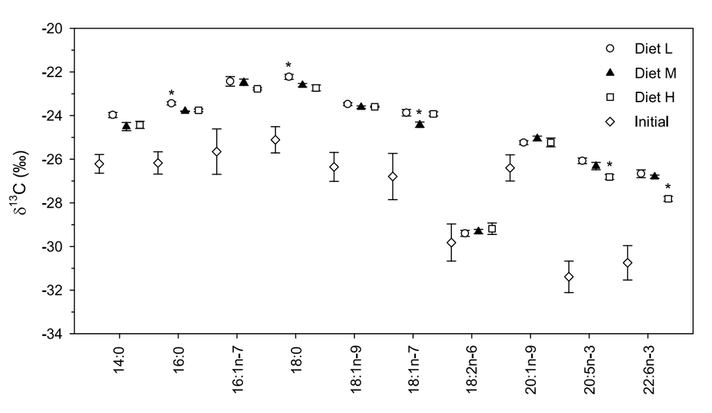

Figure 1. Original Figure 2 from Budge et al. (2023) showing liver fatty-acid δ¹³C values for initial fish and three dietary treatments.

Figure 2 from Budge et al. (2023) compares mean liver fatty-acid δ¹³C values among Atlantic pollock sampled before the feeding experiment (Initial) and fish fed three experimental diets (Diet L, Diet M, and Diet H). Error bars represent ± one standard deviation. The figure was used to assess whether dietary fat concentration influenced fatty-acid-specific carbon isotope values in liver tissue.

## Visual Critique

The figure summarizes fatty-acid δ¹³C values for multiple dietary treatments and allows broad comparisons among groups. The figure successfully presents a large amount of information in a relatively compact space and allows comparisons among treatments for ten different fatty acids.

However, the figure relies on four small black symbols to distinguish the Initial, Diet L, Diet M, and Diet H treatments. Because the symbols are similar in size, colour, and appearance, readers must continuously refer back to the legend to determine which treatment is being viewed. This weak visual hierarchy increases cognitive effort and slows interpretation. Also, ten fatty acids are displayed simultaneously, each with four treatment groups and associated standard deviations. Because many error bars overlap, especially among the dietary treatments, it becomes difficult to visually distinguish differences between groups. The figure appears crowded despite containing relatively few observations.

## Data Exploration

The paper supplied a dataset, which was explored to identify the variables used to construct Figure 2. The data contains individual measurements rather than only summary statistics, making it possible to investigate the data underlying the published figure directly.

```
[1] "MetaData"        "Mass-Length"     "Lipid Content"   "FA Mass Percent"
[5] "FA d13C"
```

```
Rows: 69
Columns: 13
$ Code          <chr> "D1-L-06", "D1-L-13", "D1-L-23", "D1-L-28", "D1-L-11", "…
$ `Sample Type` <chr> "Liver", "Liver", "Liver", "Liver", "Liver", "Liver", "L…
$ Diet          <chr> "Diet L", "Diet L", "Diet L", "Diet L", "Diet L", "Diet …
$ `14:0`        <dbl> -23.23103, -24.07998, -24.04780, -24.18952, -23.86637, -…
$ `16:0`        <dbl> -23.38532, -23.03228, -23.44920, -23.59172, -23.55913, -…
$ `16:1n-9`     <dbl> -22.11979, -22.40223, -22.02281, -22.25069, -22.41309, -…
$ `18:0`        <dbl> -22.32049, -21.93738, -22.01321, -22.23955, -22.30970, -…
$ `18:1n-9`     <dbl> -23.41047, -23.21082, -23.31129, -23.67488, -23.55617, -…
$ `18:1n-7`     <dbl> -24.18210, -23.17845, -23.55468, -23.86373, -24.19828, -…
$ `18:2n-6`     <chr> "-29.437749908174201", "-29.25968358912025", "-28.936299…
$ `20:1n-9`     <chr> "-25.180929216508197", "-24.874978904679146", "-25.38736…
$ `20:5n-3`     <dbl> -26.35105, -25.69085, -26.15673, -25.87871, -26.03974, -…
$ `22:6n-3`     <dbl> -26.70616, -25.76556, -26.94180, -26.59393, -26.79702, -…
```

```
 [1] "Code"        "Sample Type" "Diet"        "14:0"        "16:0"
 [6] "16:1n-9"     "18:0"        "18:1n-9"     "18:1n-7"     "18:2n-6"
[11] "20:1n-9"     "20:5n-3"     "22:6n-3"
```

```
# A tibble: 6 × 13
  Code    `Sample Type` Diet  `14:0` `16:0` `16:1n-9` `18:0` `18:1n-9` `18:1n-7`
  <chr>   <chr>         <chr>  <dbl>  <dbl>     <dbl>  <dbl>     <dbl>     <dbl>
1 D1-L-06 Liver         Diet…  -23.2  -23.4     -22.1  -22.3     -23.4     -24.2
2 D1-L-13 Liver         Diet…  -24.1  -23.0     -22.4  -21.9     -23.2     -23.2
3 D1-L-23 Liver         Diet…  -24.0  -23.4     -22.0  -22.0     -23.3     -23.6
4 D1-L-28 Liver         Diet…  -24.2  -23.6     -22.3  -22.2     -23.7     -23.9
5 D1-L-11 Liver         Diet…  -23.9  -23.6     -22.4  -22.3     -23.6     -24.2
6 D1-L-20 Liver         Diet…  -23.7  -23.6     -23.2  -22.6     -23.8     -23.7
# ℹ 4 more variables: `18:2n-6` <chr>, `20:1n-9` <chr>, `20:5n-3` <dbl>,
#   `22:6n-3` <dbl>
```

```
       Code Sample Type        Diet        14:0        16:0     16:1n-9
          0           0           0           0           0           0
       18:0     18:1n-9     18:1n-7     18:2n-6     20:1n-9     20:5n-3
          0           0           0           0           0           0
    22:6n-3
          0
```

First ten observations from the FA d13C dataset.

[output not shown]

### Interpretation

The supplementary workbook was explored to identify the variables used to construct Figure 2. The FA d13C worksheet contained 69 observations and 13 variables. Each observation represented an individual sample and included a sample identifier, sample type, dietary treatment, and carbon isotope values (δ¹³C) for ten fatty acids. The dataset contained both initial fish and fish fed the three experimental diets (Diet L, Diet M, and Diet H). Because individual observations were available, it was possible to investigate the variation hidden behind the published summary figure..

## Data Preparation

To reproduce Figure 2, the fatty-acid δ¹³C values were converted from a wide format, where each fatty acid occupied a separate column, into a tidy long format in which each row represented a single fatty-acid measurement.

```
Rows: 690
Columns: 5
$ Code          <chr> "D1-L-06", "D1-L-06", "D1-L-06", "D1-L-06", "D1-L-06", "…
$ `Sample Type` <chr> "Liver", "Liver", "Liver", "Liver", "Liver", "Liver", "L…
$ Diet          <chr> "Diet L", "Diet L", "Diet L", "Diet L", "Diet L", "Diet …
$ fatty_acid    <chr> "14:0", "16:0", "16:1n-9", "18:0", "18:1n-9", "18:1n-7",…
$ d13C          <dbl> -23.23103, -23.38532, -22.11979, -22.32049, -23.41047, -…
```

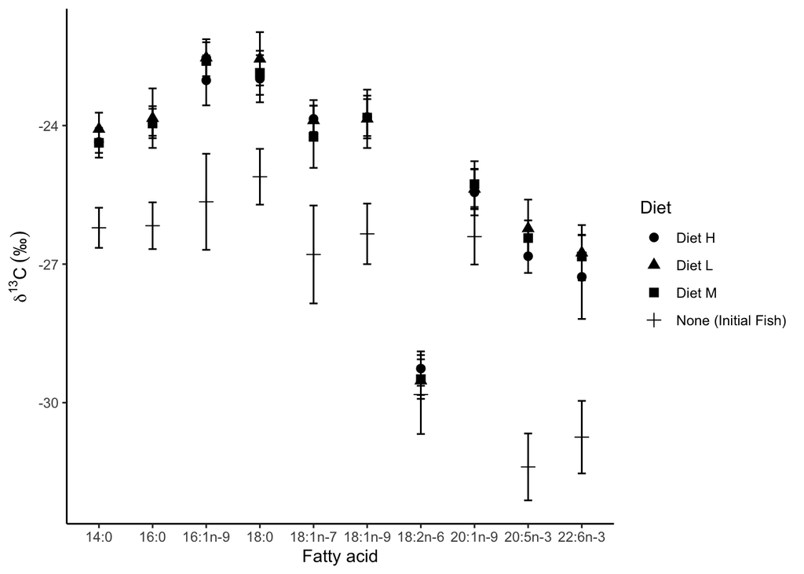

## Improved Figure

```
[1] "Diet H"              "Diet L"              "Diet M"
[4] "None (Initial Fish)"
```

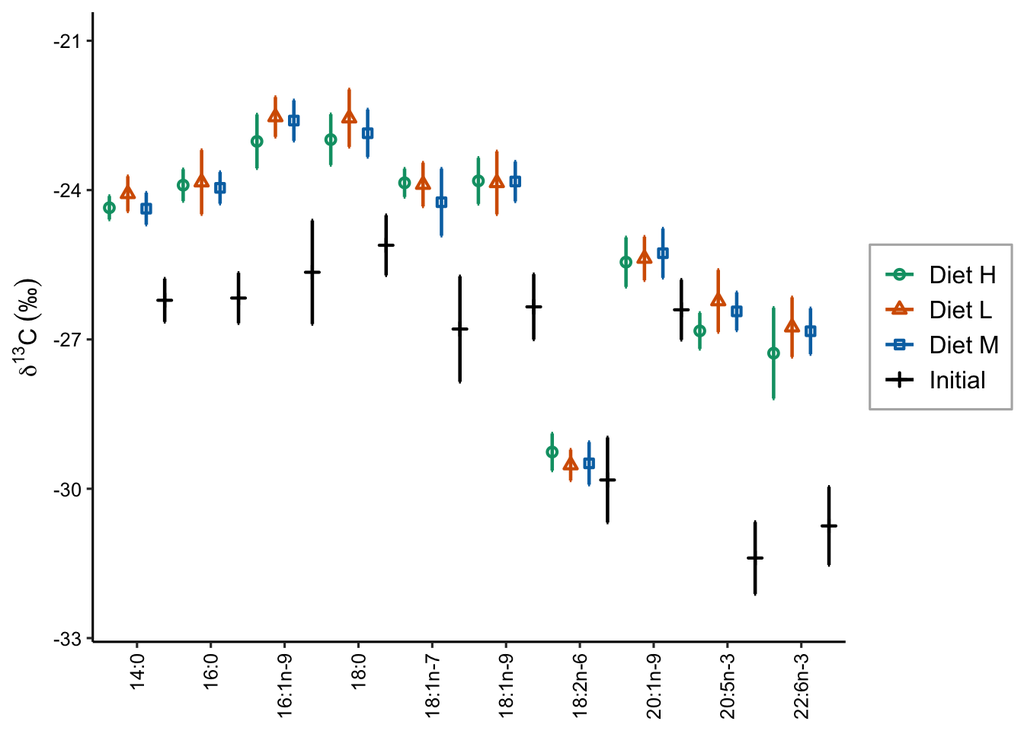

Figure 2: Mean carbon isotope signatures (δ¹³C, ‰) of selected fatty acids in Atlantic pollock fed three experimental diets (Diet H, Diet L, and Diet M) and compared with baseline values measured in fish prior to experimental feeding (Initial). Points represent mean δ¹³C values and error bars indicate ±1 standard deviation. Colours and shapes distinguish diet treatments, while black crosses denote initial fish. The revised figure improves accessibility and interpretability through the use of a high-contrast colour palette, redundant colour and shape encoding, improved label readability, and a simplified legend.

## Reflection

I made this figure with the following in mind: I wanted to preserve the original data while improving aesthetics (using a colourblind-accessible, high-contrast palette to improve discrimination among diet treatments), retaining shapes to provide redundant encoding and improve accessibility, and positioning the legend in a cleaner way to improve visual clarity.